# Campus Energy Drink Trends and Observation Patterns

## What is this dataset about?

This project investigates energy drink observations collected around University of Auckland and AUT campuses.

The dataset includes:

- drink brands
- campus locations
- building information
- quantities observed
- dates and times of observations

The goal of this analysis is to identify trends in energy drink popularity and understand how observations vary across locations and over time.

[figure not shown]

## Which energy drink brands are seen the most?

The first visualisation compares the total quantity observed for the most common drink brands.

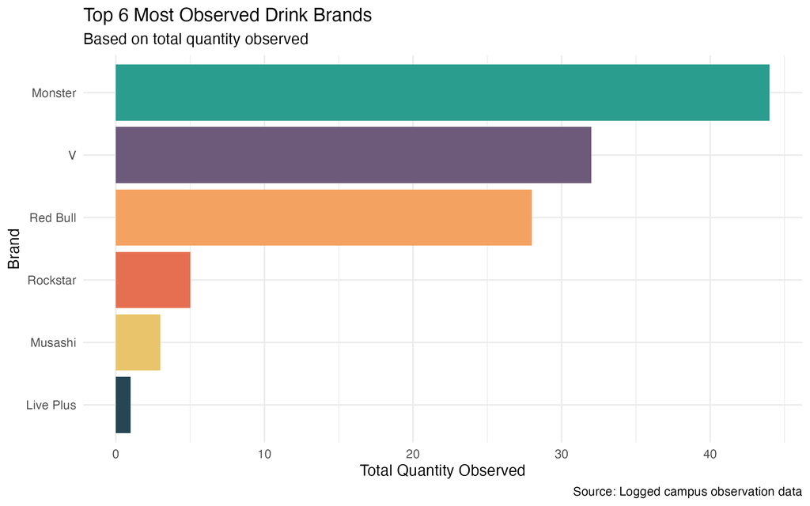

This graph shows that some brands appear much more frequently than others.

The most commonly observed drinks are Monster, Redbull and V which dominate the dataset, suggesting strong popularity differences between brands on campus.

The ranking also highlights how student preferences are concentrated around a smaller number of well-known products.

## How do drink quantities vary across campuses?

The next visualisation compares the spread of observed quantities between campuses using boxplots.

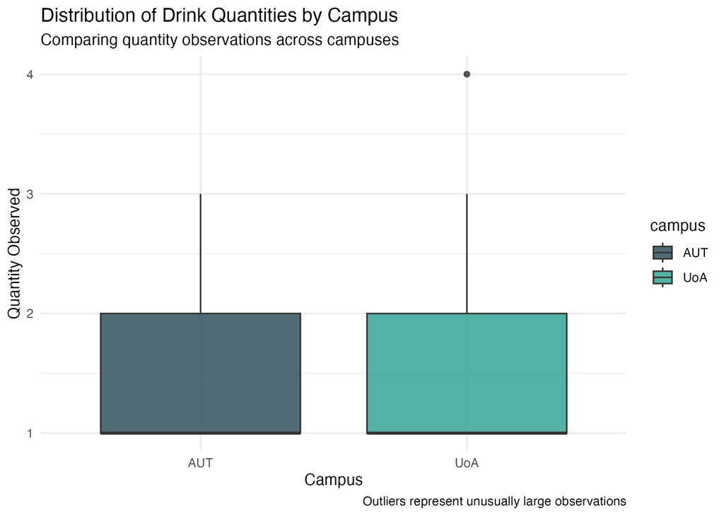

This visualisation helps compare how concentrated or spread out observations are at each campus.

Both campuses show low variability in drink quantities, which may indicate less clustering of students consuming similar drinks together.

The largest outlier in the dataset was 4 drinks observed together at UoA.

## How do observations change over time?

The final visualisation looks at total drink observations across different dates.

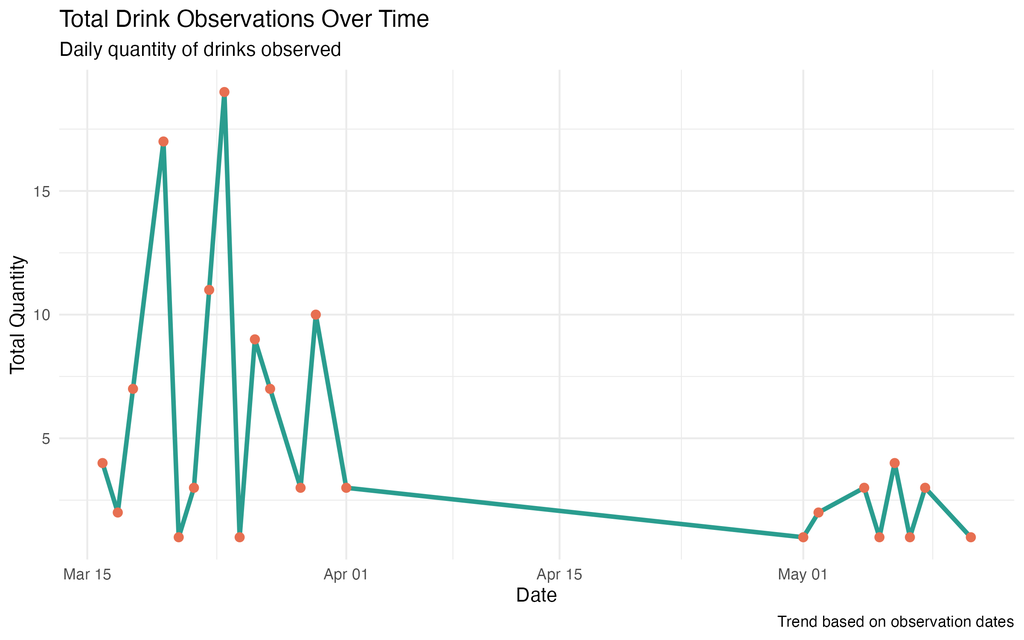

Using date information allowed trends over time to be explored.

The graph shows fluctuations in observation totals across different days. Some dates contain spikes in activity, which may reflect busier university days, assessment periods, or higher student presence on campus, although it is also likely that we took more initiative on making observations on those dates.

## Final reflections

Overall, this dataset provides insight into energy drink consumption patterns around university campuses.

The analysis demonstrated:

By combining data manipulation, visualisation, and storytelling, the project transforms raw observational data into meaningful insights about student behaviour and campus environments.